# Regression Models Course Project

Kunal Bhardwaj

2022-09-05

## Executive Summary

Motor Trend Magazine is interested in exploring the relationship between a set of variables and miles per gallon (MPG). They are particularly interested in the following two questions:

1. Is an automatic or manual transmission better for MPG?
2. Quantify the MPG difference between automatic and manual transmissions

## Exploratory Data Analysis

```r
#Data set:
library(datasets)
data(mtcars)

#Sample view of the data set:
head(mtcars)
```

```
##                    mpg cyl disp  hp drat    wt  qsec vs am gear carb
## Mazda RX4         21.0   6  160 110 3.90 2.620 16.46  0  1    4    4
## Mazda RX4 Wag     21.0   6  160 110 3.90 2.875 17.02  0  1    4    4
## Datsun 710        22.8   4  108  93 3.85 2.320 18.61  1  1    4    1
## Hornet 4 Drive    21.4   6  258 110 3.08 3.215 19.44  1  0    3    1
## Hornet Sportabout 18.7   8  360 175 3.15 3.440 17.02  0  0    3    2
## Valiant           18.1   6  225 105 2.76 3.460 20.22  1  0    3    1
```

```r
#Statistical summary of MPG variable:
summary(mtcars$mpg)
```

```
##    Min. 1st Qu.  Median    Mean 3rd Qu.    Max.
##   10.40   15.43   19.20   20.09   22.80   33.90
```

```r
#Automatic vs Manual Transmission stats:
transStats = split(mtcars$mpg, mtcars$am)

#Mean:
sapply(transStats, mean)
```

```
##        0        1
## 17.14737 24.39231
```

```r
#Standard Deviation:
sapply(transStats, sd)
```

```
##        0        1
## 3.833966 6.166504
```

```r
#Range:
sapply(transStats, range)
```

```
##         0    1
## [1,] 10.4 15.0
## [2,] 24.4 33.9
```

```r
#Automatic vs Manual Transmission Hypothesis Test:
autoTrans <- mtcars[mtcars$am == "0",]
manTrans <- mtcars[mtcars$am == "1",]
t.test(autoTrans$mpg, manTrans$mpg)
```

```
##
##  Welch Two Sample t-test
##
## data:  autoTrans$mpg and manTrans$mpg
## t = -3.7671, df = 18.332, p-value = 0.001374
## alternative hypothesis: true difference in means is not equal to 0
## 95 percent confidence interval:
##  -11.280194  -3.209684
## sample estimates:
## mean of x mean of y
##  17.14737  24.39231
```

## Regression Models

1. Linear Regression Model

A simple linear regression model is first conducted to find out how much of an affect transmission type actually has on gas mileage performance, which is our initial claim supported by our our preliminary exploratory data analysis.

```r
fit1 <- lm(mpg ~ am, mtcars)
summary(fit1)
```

```
##
## Call:
## lm(formula = mpg ~ am, data = mtcars)
##
## Residuals:
##     Min      1Q  Median      3Q     Max
## -9.3923 -3.0923 -0.2974  3.2439  9.5077
##
## Coefficients:
##             Estimate Std. Error t value Pr(>|t|)
## (Intercept)   17.147      1.125  15.247 1.13e-15 ***
## am             7.245      1.764   4.106 0.000285 ***
## ---
## Signif. codes:  0 '***' 0.001 '**' 0.01 '*' 0.05 '.' 0.1 ' ' 1
##
## Residual standard error: 4.902 on 30 degrees of freedom
## Multiple R-squared:  0.3598, Adjusted R-squared:  0.3385
## F-statistic: 16.86 on 1 and 30 DF,  p-value: 0.000285
```

The p-value are low (0.000285) and R-Squared is 0.3385. Thus, based upon the R-squared value, transmission types only explain 33.85% of the MPG performance. Therefore the Linear Regression Model is inadequate in deciding the impact of transmission type to MPG.

Thus, a multivariable Regression Model has been carried out, choosing transmission type, Cylinder count, Horsepower and weight as predictors.

2. Multivariable Regression Model

```r
fit2 <- lm(mpg~am + cyl + hp + wt, mtcars)
summary(fit2)
```

```
##
## Call:
## lm(formula = mpg ~ am + cyl + hp + wt, data = mtcars)
##
## Residuals:
##     Min      1Q  Median      3Q     Max
## -3.4765 -1.8471 -0.5544  1.2758  5.6608
##
## Coefficients:
##             Estimate Std. Error t value Pr(>|t|)
## (Intercept) 36.14654    3.10478  11.642 4.94e-12 ***
## am           1.47805    1.44115   1.026   0.3142
## cyl         -0.74516    0.58279  -1.279   0.2119
## hp          -0.02495    0.01365  -1.828   0.0786 .
## wt          -2.60648    0.91984  -2.834   0.0086 **
## ---
## Signif. codes:  0 '***' 0.001 '**' 0.01 '*' 0.05 '.' 0.1 ' ' 1
##
## Residual standard error: 2.509 on 27 degrees of freedom
## Multiple R-squared:  0.849,  Adjusted R-squared:  0.8267
## F-statistic: 37.96 on 4 and 27 DF,  p-value: 1.025e-10
```

The R-squared value improved to 0.8267 but the p-value for transmission type is no longer significant.

This second model provided the following results: Thus, based upon the R-squared value, these variables explain 82.67% of the MPG performance.

## Conclusion

1. With a p < 0.05 confidence, cars with manual transmission have more miles per gallon (MPG) than automatic transmissions.
2. If we have more observations available, with same cars model, using manual and automatic transmission, could help us better answer the second question about: Quantify the MPG difference between automatica and manual transmissions? The database with only 32 observations may not have been enough to answer more clearly the second question.

## Appendix

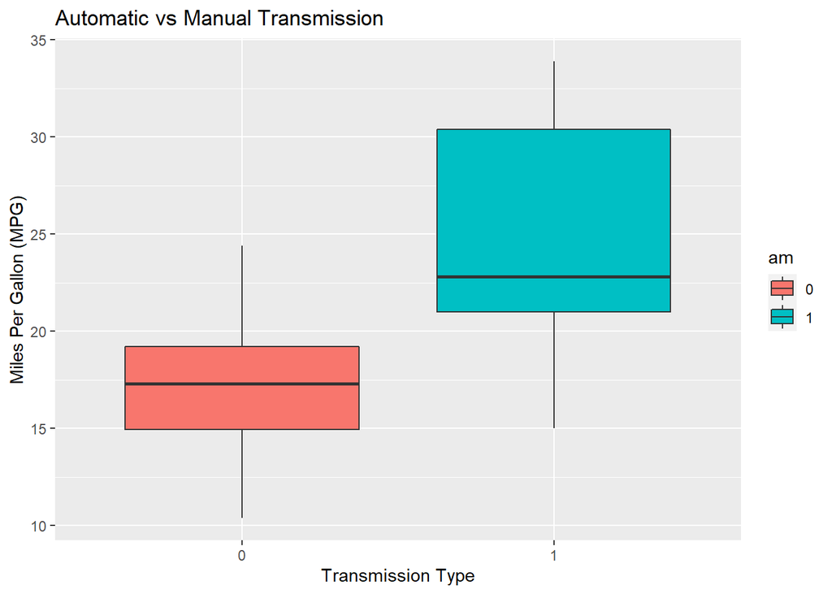

```r
#Visualization of Automatic vs Manual Transmission:
library(ggplot2)
mtcars$am <- as.factor(mtcars$am)
transTyp <- ggplot(aes(x=am, y=mpg), data=mtcars) + geom_boxplot(aes(fill=am))
transTyp <- transTyp + labs(title = "Automatic vs Manual Transmission") + xlab("Transmission Type") + ylab("Miles Per Gallon (MPG)")
transTyp
```

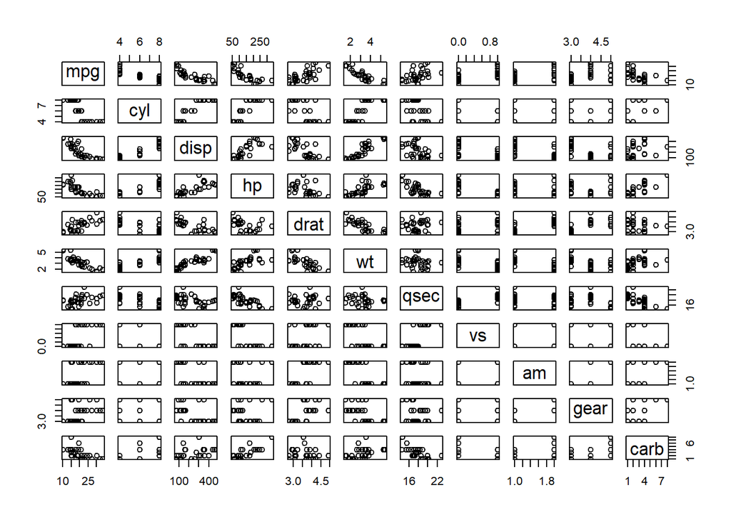

```r
#Scatterplot matrix of the dataset:
pairs(mpg ~ ., data = mtcars)
```

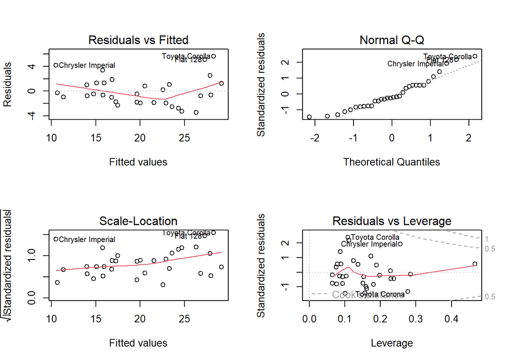

```r
#Scatterplots of the multivariable regression model residuals:
par(mfrow = c(2,2))
plot(fit2)
```